# Multi-Layer Networks - Part2

### Lecture Date: 2025-02-14

# PyTorch Setup for Neural Networks

```python
# Core Boilerplate Imports for PyTorch/Lightning
import numpy as np
import torch
import lightning.pytorch as pl
from torchinfo import summary
from torchview import draw_graph
import torchmetrics
import torchvision # Image Data Sets/Tools
import matplotlib.pyplot as plt
```

```python
print("GPU is present:",torch.cuda.is_available())
```

```
GPU is present: False
```

# Standard data set preparations

1. Load an image data set and flatten 3D tensors to 1D tensors (vectors)
2. Create matrix of feature vectors (from flattened images)
3. Create vector of class labels (pulled separately this time from the torchvision module)

### CIFAR 10

Original: https://www.cs.toronto.edu/~kriz/cifar.html

```python
# CIFAR 10
training_dataset = torchvision.datasets.CIFAR10(root='~/datasets',download=True, train=True)
testing_dataset = torchvision.datasets.CIFAR10(root='~/datasets',download=True, train=False)
```

```
Files already downloaded and verified
Files already downloaded and verified
```

```python
training_dataset.data.shape
```

```
(50000, 32, 32, 3)
```

```python
testing_dataset.data.shape
```

```
(10000, 32, 32, 3)
```

```python
len(training_dataset.targets)
```

```
50000
```

```python
len(testing_dataset.targets)
```

```
10000
```

```python
# Pick an image...
i = 1
```

```python
training_dataset.targets[i]
```

```
9
```

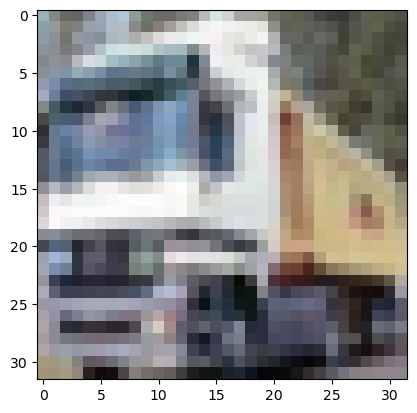

```python
plt.imshow(training_dataset.data[i])
plt.show()
```

```python
# Make a re-shaping tuple
training_dataset.data.shape[0:1] + (-1,)
```

```
(50000, -1)
```

```python
np.max(training_dataset.data)
```

```
255
```

```python
np.min(training_dataset.data)
```

```
0
```

```python
x_train = training_dataset.data.reshape(training_dataset.data.shape[0:1] + (-1,))
x_train = (x_train / 127.5) - 1.0
y_train = np.array(training_dataset.targets)
x_train.shape
```

```
(50000, 3072)
```

```python
x_test = testing_dataset.data.reshape(testing_dataset.data.shape[0:1] + (-1,))
x_test = (x_test / 127.5) - 1.0
y_test = np.array(testing_dataset.targets)
x_test.shape
```

```
(10000, 3072)
```

```python
np.max(x_train)
```

```
1.0
```

```python
np.min(x_train)
```

```
-1.0
```

## DataModule for CIFAR10

This creates the data module for CIFAR10, which will create `DataLoader` instances for the training/validation/testing splits of this data that can be used by the `Trainer` below...

```python
class CIFAR10DataModule(pl.LightningDataModule):
    def __init__(self,
                 batch_size = 128,
                 val_split = 0.2,
                 num_workers = 4,
                 location = "~/datasets",
                 **kwargs):
        super().__init__(**kwargs)
        self.batch_size = batch_size
        self.val_split = val_split
        self.num_workers = num_workers
        self.location = location
        self.input_shape = 3072
        self.output_shape = 10
        self.data_train = None
        self.data_val = None
        self.data_test = None

    def setup(self, stage: str):
        if (stage == 'fit' or \
            stage == 'validate') and \
            not(self.data_train and self.data_val):
            training_dataset = torchvision.datasets.CIFAR10(root=self.location,download=True, train=True)
            x_train = training_dataset.data.reshape(training_dataset.data.shape[0:1] + (-1,))
            x_train = (x_train / 127.5) - 1.0
            y_train = np.array(training_dataset.targets)
            rng = np.random.default_rng(0)
            permutation = rng.permutation(x_train.shape[0])
            split_point = int(x_train.shape[0]*(1.0-self.val_split))
            self.data_train = list(zip(torch.Tensor(x_train[permutation[:split_point]]).to(torch.float32),
                                       torch.Tensor(y_train[permutation[:split_point]]).to(torch.long)))
            self.data_val = list(zip(torch.Tensor(x_train[permutation[split_point:]]).to(torch.float32),
                                     torch.Tensor(y_train[permutation[split_point:]]).to(torch.long)))
        if (stage == 'test' or \
            stage == 'predict') and \
            not self.data_test:
            testing_dataset = torchvision.datasets.CIFAR10(root=self.location,download=True, train=False)
            x_test = testing_dataset.data.reshape(testing_dataset.data.shape[0:1] + (-1,))
            x_test = (x_test / 127.5) - 1.0
            y_test = np.array(testing_dataset.targets)
            self.data_test = list(zip(torch.Tensor(x_test).to(torch.float32),
                                      torch.Tensor(y_test).to(torch.long)))

    def train_dataloader(self):
        return torch.utils.data.DataLoader(self.data_train,
                                           batch_size=self.batch_size,
                                           num_workers=self.num_workers,
                                           shuffle=True)

    def val_dataloader(self):
        return torch.utils.data.DataLoader(self.data_val,
                                           batch_size=self.batch_size,
                                           num_workers=self.num_workers,
                                           shuffle=False)

    def test_dataloader(self):
        return torch.utils.data.DataLoader(self.data_test,
                                           batch_size=self.batch_size,
                                           num_workers=self.num_workers,
                                           shuffle=False)

    def predict_dataloader(self):
        return torch.utils.data.DataLoader(self.data_test,
                                           batch_size=self.batch_size,
                                           num_workers=self.num_workers,
                                           shuffle=False)
```

### MNIST

Info: https://en.wikipedia.org/wiki/MNIST_database

```python
# MNIST
training_dataset = torchvision.datasets.MNIST(root='~/datasets',download=True, train=True)
testing_dataset = torchvision.datasets.MNIST(root='~/datasets',download=True, train=False)
```

```python
training_dataset.data.shape
```

```
torch.Size([60000, 28, 28])
```

```python
testing_dataset.data.shape
```

```
torch.Size([10000, 28, 28])
```

```python
len(training_dataset.targets)
```

```
60000
```

```python
len(testing_dataset.targets)
```

```
10000
```

```python
# Pick an image...
i = 0
```

```python
training_dataset.targets[i]
```

```
tensor(5)
```

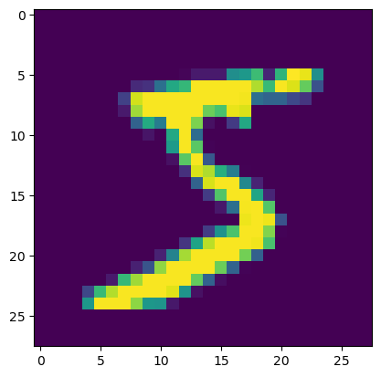

```python
plt.imshow(training_dataset.data[i])
plt.show()
```

```python
# Make a re-shaping tuple
training_dataset.data.shape[0:1] + (-1,)
```

```
torch.Size([60000, -1])
```

Note that MNIST was already in tensor form - only converting to numpy to suppress some warning messages from PyTorch when instantiating the DataLoaders...

```python
x_train = training_dataset.data.reshape(training_dataset.data.shape[0:1] + (-1,)).detach().numpy()
x_train = (x_train / 127.5) - 1.0
y_train = np.array(training_dataset.targets)
x_train.shape
```

```
(60000, 784)
```

```python
x_test = testing_dataset.data.reshape(testing_dataset.data.shape[0:1] + (-1,)).detach().numpy()
x_test = (x_test / 127.5) - 1.0
y_test = np.array(testing_dataset.targets)
x_test.shape
```

```
(10000, 784)
```

```python
class MNISTDataModule(pl.LightningDataModule):
    def __init__(self,
                 batch_size = 128,
                 val_split = 0.2,
                 num_workers = 4,
                 location = "~/datasets",
                 **kwargs):
        super().__init__(**kwargs)
        self.batch_size = batch_size
        self.val_split = val_split
        self.num_workers = num_workers
        self.location = "~/datasets"
        self.input_shape = 784
        self.output_shape = 10
        self.data_train = None
        self.data_val = None
        self.data_test = None

    def setup(self, stage: str):
        if (stage == 'fit' or \
            stage == 'validate') and \
            not(self.data_train and self.data_val):
            training_dataset = torchvision.datasets.MNIST(root=self.location,download=True, train=True)
            x_train = training_dataset.data.reshape(training_dataset.data.shape[0:1] + (-1,))
            x_train = (x_train / 127.5) - 1.0
            y_train = np.array(training_dataset.targets)
            rng = np.random.default_rng(0)
            permutation = rng.permutation(x_train.shape[0])
            split_point = int(x_train.shape[0]*(1.0-self.val_split))
            self.data_train = list(zip(torch.Tensor(x_train[permutation[:split_point]]).to(torch.float32),
                                       torch.Tensor(y_train[permutation[:split_point]]).to(torch.long)))
            self.data_val = list(zip(torch.Tensor(x_train[permutation[split_point:]]).to(torch.float32),
                                     torch.Tensor(y_train[permutation[split_point:]]).to(torch.long)))
        if (stage == 'test' or \
            stage == 'predict') and \
            not self.data_test:
            testing_dataset = torchvision.datasets.MNIST(root=self.location,download=True, train=False)
            x_test = testing_dataset.data.reshape(testing_dataset.data.shape[0:1] + (-1,))
            x_test = (x_test / 127.5) - 1.0
            y_test = np.array(testing_dataset.targets)
            self.data_test = list(zip(torch.Tensor(x_test).to(torch.float32),
                                      torch.Tensor(y_test).to(torch.long)))

    def train_dataloader(self):
        return torch.utils.data.DataLoader(self.data_train,
                                           batch_size=self.batch_size,
                                           num_workers=self.num_workers,
                                           shuffle=True)

    def val_dataloader(self):
        return torch.utils.data.DataLoader(self.data_val,
                                           batch_size=self.batch_size,
                                           num_workers=self.num_workers,
                                           shuffle=False)

    def test_dataloader(self):
        return torch.utils.data.DataLoader(self.data_test,
                                           batch_size=self.batch_size,
                                           num_workers=self.num_workers,
                                           shuffle=False)

    def predict_dataloader(self):
        return torch.utils.data.DataLoader(self.data_test,
                                           batch_size=self.batch_size,
                                           num_workers=self.num_workers,
                                           shuffle=False)
```

# Select a dataset here...

```python
# data_module = MNISTDataModule()
# data_module = CIFAR10DataModule()
```

# Neural Network

```python
class HiddenLayer(pl.LightningModule):
        def __init__(self,
                 input_size,
                 output_size,
                 **kwargs):
            super().__init__(**kwargs)
            self.net_input = torch.nn.Linear(input_size,
                                             output_size)
            self.activation = torch.nn.Tanh()
        def forward(self, x):
            y = x
            y = self.net_input(y)
            y = self.activation(y)
            return y
```

```python
# Define model
class NeuralNetwork(pl.LightningModule):
    def __init__(self,
                 input_size,
                 output_size,
                 **kwargs):
        super().__init__(**kwargs)
        hidden_size = 400
        self.hidden = [HiddenLayer(input_size,
                                   hidden_size)]
        self.hidden = self.hidden + [HiddenLayer(hidden_size,hidden_size) for i in range(3)]
        self.hidden = torch.nn.Sequential(*self.hidden)
        self.output_net = torch.nn.Linear(hidden_size,
                                          output_size)
        self.output_activation = torch.nn.Softmax(dim=-1)
        self.accuracy = torchmetrics.classification.Accuracy(task='multiclass',
                                                             num_classes=output_size)
        self.cce_loss = torch.nn.CrossEntropyLoss()

    def forward(self, x):
        y = x
        y = self.hidden(y)
        y = self.output_net(y)
        return y

    # Note - not a PyTorch Lightning Function
    def predict(self, x):
        y = self(x)
        y = self.output_activation(y)
        return y

    def configure_optimizers(self):
        optimizer = torch.optim.SGD(self.parameters(), lr=1e-2)
        return optimizer

    def predict_step(self, predict_batch, batch_idx):
        x, y_true = predict_batch
        y_pred = self.predict(x)
        return y_pred, y_true

    def training_step(self, train_batch, batch_idx):
        x, y_true = train_batch
        y_pred = self(x)
        loss = self.cce_loss(y_pred, y_true)
        acc = self.accuracy(y_pred, y_true)
        self.log('train_loss', loss, on_step=False, on_epoch=True)
        self.log('train_acc', acc, on_step=False, on_epoch=True)
        return loss

    def validation_step(self, val_batch, batch_idx):
        x, y_true = val_batch
        y_pred = self(x)
        loss = self.cce_loss(y_pred, y_true)
        acc = self.accuracy(y_pred, y_true)
        self.log('val_loss', loss, on_step=False, on_epoch=True)
        self.log('val_acc', acc, on_step=False, on_epoch=True)
        return loss

    def test_step(self, test_batch, batch_idx):
        x, y_true = test_batch
        y_pred = self(x)
        loss = self.cce_loss(y_pred, y_true)
        acc = self.accuracy(y_pred, y_true)
        self.log('test_loss', loss, on_step=False, on_epoch=True)
        self.log('test_acc', acc, on_step=False, on_epoch=True)
        return loss
model = NeuralNetwork(data_module.input_shape,
                      data_module.output_shape)
print(model)
```

```
NeuralNetwork(
  (hidden): Sequential(
    (0): HiddenLayer(
      (net_input): Linear(in_features=784, out_features=400, bias=True)
      (activation): Tanh()
    )
    (1): HiddenLayer(
      (net_input): Linear(in_features=400, out_features=400, bias=True)
      (activation): Tanh()
    )
    (2): HiddenLayer(
      (net_input): Linear(in_features=400, out_features=400, bias=True)
      (activation): Tanh()
    )
    (3): HiddenLayer(
      (net_input): Linear(in_features=400, out_features=400, bias=True)
      (activation): Tanh()
    )
  )
  (output_net): Linear(in_features=400, out_features=10, bias=True)
  (output_activation): Softmax(dim=-1)
  (accuracy): MulticlassAccuracy()
  (cce_loss): CrossEntropyLoss()
)
```

# Net Visualization/Summaries

```python
model_graph = draw_graph(model,
                         input_size=(32,data_module.input_shape),
                         depth=2)
model_graph.visual_graph
```

[figure not shown]

```python
summary(model, input_size=(5,data_module.input_shape))
```

```
==========================================================================================
Layer (type:depth-idx)                   Output Shape              Param #
==========================================================================================
NeuralNetwork                            [5, 10]                   --
├─Sequential: 1-1                        [5, 400]                  --
│    └─HiddenLayer: 2-1                  [5, 400]                  --
│    │    └─Linear: 3-1                  [5, 400]                  314,000
│    │    └─Tanh: 3-2                    [5, 400]                  --
│    └─HiddenLayer: 2-2                  [5, 400]                  --
│    │    └─Linear: 3-3                  [5, 400]                  160,400
│    │    └─Tanh: 3-4                    [5, 400]                  --
│    └─HiddenLayer: 2-3                  [5, 400]                  --
│    │    └─Linear: 3-5                  [5, 400]                  160,400
│    │    └─Tanh: 3-6                    [5, 400]                  --
│    └─HiddenLayer: 2-4                  [5, 400]                  --
│    │    └─Linear: 3-7                  [5, 400]                  160,400
│    │    └─Tanh: 3-8                    [5, 400]                  --
├─Linear: 1-2                            [5, 10]                   4,010
==========================================================================================
Total params: 799,210
Trainable params: 799,210
Non-trainable params: 0
Total mult-adds (Units.MEGABYTES): 4.00
==========================================================================================
Input size (MB): 0.02
Forward/backward pass size (MB): 0.06
Params size (MB): 3.20
Estimated Total Size (MB): 3.28
==========================================================================================
```

Passing data into the network (and getting back the result).

```python
data_module.setup('predict')
a_batch = next(iter(data_module.predict_dataloader()))
```

```python
model.predict(a_batch[0].to(model.device)).cpu().detach()
```

```
tensor([[0.0965, 0.1010, 0.1041,  ..., 0.1010, 0.1006, 0.0897],
        [0.0974, 0.0978, 0.1031,  ..., 0.0942, 0.1053, 0.0995],
        [0.0983, 0.0988, 0.1038,  ..., 0.0980, 0.1069, 0.0937],
        ...,
        [0.0957, 0.0962, 0.0997,  ..., 0.0983, 0.1019, 0.0945],
        [0.1003, 0.0956, 0.1047,  ..., 0.1008, 0.1075, 0.0905],
        [0.0957, 0.1013, 0.0991,  ..., 0.0984, 0.1076, 0.0895]])
```

Use `argmax`: assume the highest predicted probability out of all 10 classes is the *answer* that the network is providing. This is the **most confident** prediction even if it's not very confident (which would be the case when most of the probabilities are the same. This would always be `0.1` for all 10 classes for these networks).

```python
model.predict(a_batch[0].to(model.device)).cpu().detach().argmax(-1)
```

```
tensor([2, 8, 8, 1, 8, 8, 2, 5, 8, 8, 8, 8, 6, 8, 4, 7, 8, 4, 4, 8, 2, 8, 8, 4,
        8, 8, 8, 8, 7, 8, 4, 8, 8, 8, 7, 6, 4, 8, 4, 4, 8, 5, 8, 3, 4, 4, 8, 5,
        8, 8, 8, 2, 8, 8, 8, 4, 8, 8, 8, 2, 8, 3, 8, 2, 4, 5, 8, 8, 4, 4, 4, 8,
        8, 4, 4, 5, 8, 8, 4, 4, 8, 8, 3, 8, 8, 8, 4, 7, 8, 8, 8, 6, 4, 4, 3, 8,
        2, 4, 5, 8, 8, 7, 4, 8, 8, 8, 6, 2, 8, 3, 5, 4, 8, 8, 4, 5, 8, 8, 4, 8,
        8, 3, 6, 8, 6, 5, 8, 8])
```

And here are the corresponding targets:

```python
a_batch[1]
```

```
tensor([7, 2, 1, 0, 4, 1, 4, 9, 5, 9, 0, 6, 9, 0, 1, 5, 9, 7, 3, 4, 9, 6, 6, 5,
        4, 0, 7, 4, 0, 1, 3, 1, 3, 4, 7, 2, 7, 1, 2, 1, 1, 7, 4, 2, 3, 5, 1, 2,
        4, 4, 6, 3, 5, 5, 6, 0, 4, 1, 9, 5, 7, 8, 9, 3, 7, 4, 6, 4, 3, 0, 7, 0,
        2, 9, 1, 7, 3, 2, 9, 7, 7, 6, 2, 7, 8, 4, 7, 3, 6, 1, 3, 6, 9, 3, 1, 4,
        1, 7, 6, 9, 6, 0, 5, 4, 9, 9, 2, 1, 9, 4, 8, 7, 3, 9, 7, 4, 4, 4, 9, 2,
        5, 4, 7, 6, 7, 9, 0, 5])
```

```python
torch.count_nonzero(a_batch[1] == model.predict(a_batch[0].to(model.device)).cpu().detach().argmax(-1))
```

```
tensor(3)
```

# PyTorch Lightning

### Loggers and Trainers

```python
logger = pl.loggers.CSVLogger("logs",name="multilayer_example",)
trainer = pl.Trainer(max_epochs=10,logger=logger,
                     enable_progress_bar=True,
                     log_every_n_steps=0,
                     callbacks=[pl.callbacks.TQDMProgressBar(refresh_rate=20)])
```

```
GPU available: False, used: False
TPU available: False, using: 0 TPU cores
HPU available: False, using: 0 HPUs
```

```python
result = trainer.validate(model, dataloaders=data_module)
```

```
Validation: |          | 0/? [00:00<?, ?it/s]
```

```
┏━━━━━━━━━━━━━━━━━━━━━━━━━━━┳━━━━━━━━━━━━━━━━━━━━━━━━━━━┓
┃      Validate metric      ┃       DataLoader 0        ┃
┡━━━━━━━━━━━━━━━━━━━━━━━━━━━╇━━━━━━━━━━━━━━━━━━━━━━━━━━━┩
│          val_acc          │    0.07708333432674408    │
│         val_loss          │     2.30686354637146      │
└───────────────────────────┴───────────────────────────┘
```

```python
result = trainer.fit(model, data_module)
```

```
  | Name              | Type               | Params | Mode
-----------------------------------------------------------------
0 | hidden            | Sequential         | 795 K  | train
1 | output_net        | Linear             | 4.0 K  | train
2 | output_activation | Softmax            | 0      | train
3 | accuracy          | MulticlassAccuracy | 0      | train
4 | cce_loss          | CrossEntropyLoss   | 0      | train
-----------------------------------------------------------------
799 K     Trainable params
0         Non-trainable params
799 K     Total params
3.197     Total estimated model params size (MB)
17        Modules in train mode
0         Modules in eval mode
```

```
Sanity Checking: |          | 0/? [00:00<?, ?it/s]
```

```
Training: |          | 0/? [00:00<?, ?it/s]
```

```
Validation: |          | 0/? [00:00<?, ?it/s]
```

```
Validation: |          | 0/? [00:00<?, ?it/s]
```

```
Validation: |          | 0/? [00:00<?, ?it/s]
```

```
Validation: |          | 0/? [00:00<?, ?it/s]
```

```
Validation: |          | 0/? [00:00<?, ?it/s]
```

```
Validation: |          | 0/? [00:00<?, ?it/s]
```

```
Validation: |          | 0/? [00:00<?, ?it/s]
```

```
Validation: |          | 0/? [00:00<?, ?it/s]
```

```
Validation: |          | 0/? [00:00<?, ?it/s]
```

```
Validation: |          | 0/? [00:00<?, ?it/s]
```

```
`Trainer.fit` stopped: `max_epochs=10` reached.
```

```python
result = trainer.validate(model, data_module)
```

```
Validation: |          | 0/? [00:00<?, ?it/s]
```

```
┏━━━━━━━━━━━━━━━━━━━━━━━━━━━┳━━━━━━━━━━━━━━━━━━━━━━━━━━━┓
┃      Validate metric      ┃       DataLoader 0        ┃
┡━━━━━━━━━━━━━━━━━━━━━━━━━━━╇━━━━━━━━━━━━━━━━━━━━━━━━━━━┩
│          val_acc          │     0.921500027179718     │
│         val_loss          │    0.2710190713405609     │
└───────────────────────────┴───────────────────────────┘
```

```python
result
```

```
[{'val_loss': 0.2710190713405609, 'val_acc': 0.921500027179718}]
```

### Remember: Don't use this until the very end for each model...

```python
test_result = trainer.test(model, data_module)
```

```
Testing: |          | 0/? [00:00<?, ?it/s]
```

```
┏━━━━━━━━━━━━━━━━━━━━━━━━━━━┳━━━━━━━━━━━━━━━━━━━━━━━━━━━┓
┃        Test metric        ┃       DataLoader 0        ┃
┡━━━━━━━━━━━━━━━━━━━━━━━━━━━╇━━━━━━━━━━━━━━━━━━━━━━━━━━━┩
│         test_acc          │    0.9280999898910522     │
│         test_loss         │    0.26001298427581787    │
└───────────────────────────┴───────────────────────────┘
```

```python
test_result[0]['test_acc']
```

```
0.9280999898910522
```

# Plotting Learning Curves

```python
import pandas as pd
```

```python
results = pd.read_csv(logger.log_dir+"/metrics.csv",delimiter=',')
```

```python
results
```

|  | epoch | step | test_acc | test_loss | train_acc | train_loss | val_acc | val_loss |
| --- | --- | --- | --- | --- | --- | --- | --- | --- |
| 0 | 0 | 0 | NaN | NaN | NaN | NaN | 0.077083 | 2.306864 |
| 1 | 0 | 374 | NaN | NaN | NaN | NaN | 0.698083 | 1.113140 |
| 2 | 0 | 374 | NaN | NaN | 0.501542 | 1.866268 | NaN | NaN |
| 3 | 1 | 749 | NaN | NaN | NaN | NaN | 0.848917 | 0.546164 |
| 4 | 1 | 749 | NaN | NaN | 0.803688 | 0.746010 | NaN | NaN |
| 5 | 2 | 1124 | NaN | NaN | NaN | NaN | 0.879750 | 0.422559 |
| 6 | 2 | 1124 | NaN | NaN | 0.870604 | 0.471709 | NaN | NaN |
| 7 | 3 | 1499 | NaN | NaN | NaN | NaN | 0.891167 | 0.373606 |
| 8 | 3 | 1499 | NaN | NaN | 0.889875 | 0.392202 | NaN | NaN |
| 9 | 4 | 1874 | NaN | NaN | NaN | NaN | 0.899667 | 0.346602 |
| 10 | 4 | 1874 | NaN | NaN | 0.899000 | 0.353344 | NaN | NaN |
| 11 | 5 | 2249 | NaN | NaN | NaN | NaN | 0.905833 | 0.321776 |
| 12 | 5 | 2249 | NaN | NaN | 0.906333 | 0.327249 | NaN | NaN |
| 13 | 6 | 2624 | NaN | NaN | NaN | NaN | 0.910083 | 0.307696 |
| 14 | 6 | 2624 | NaN | NaN | 0.911708 | 0.307165 | NaN | NaN |
| 15 | 7 | 2999 | NaN | NaN | NaN | NaN | 0.914500 | 0.289318 |
| 16 | 7 | 2999 | NaN | NaN | 0.916062 | 0.290435 | NaN | NaN |
| 17 | 8 | 3374 | NaN | NaN | NaN | NaN | 0.916083 | 0.279685 |
| 18 | 8 | 3374 | NaN | NaN | 0.920125 | 0.275371 | NaN | NaN |
| 19 | 9 | 3749 | NaN | NaN | NaN | NaN | 0.921500 | 0.271019 |
| 20 | 9 | 3749 | NaN | NaN | 0.924542 | 0.261800 | NaN | NaN |
| 21 | 10 | 3750 | NaN | NaN | NaN | NaN | 0.921500 | 0.271019 |
| 22 | 10 | 3750 | 0.9281 | 0.260013 | NaN | NaN | NaN | NaN |

```python
results['epoch']
```

```
0      0
1      0
2      0
3      1
4      1
5      2
6      2
7      3
8      3
9      4
10     4
11     5
12     5
13     6
14     6
15     7
16     7
17     8
18     8
19     9
20     9
21    10
22    10
Name: epoch, dtype: int64
```

```python
results['train_loss']
```

```
0          NaN
1          NaN
2     1.866268
3          NaN
4     0.746010
5          NaN
6     0.471709
7          NaN
8     0.392202
9          NaN
10    0.353344
11         NaN
12    0.327249
13         NaN
14    0.307165
15         NaN
16    0.290435
17         NaN
18    0.275371
19         NaN
20    0.261800
21         NaN
22         NaN
Name: train_loss, dtype: float64
```

```python
results['val_loss']
```

```
0     2.306864
1     1.113140
2          NaN
3     0.546164
4          NaN
5     0.422559
6          NaN
7     0.373606
8          NaN
9     0.346602
10         NaN
11    0.321776
12         NaN
13    0.307696
14         NaN
15    0.289318
16         NaN
17    0.279685
18         NaN
19    0.271019
20         NaN
21    0.271019
22         NaN
Name: val_loss, dtype: float64
```

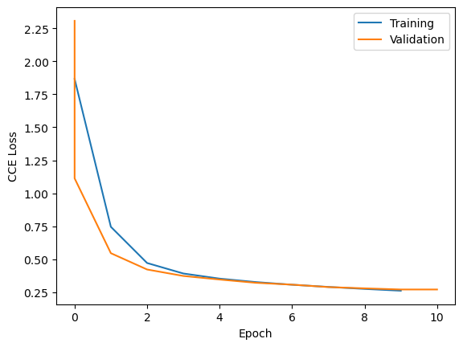

```python
plt.plot(results["epoch"][np.logical_not(np.isnan(results["train_loss"]))],
         results["train_loss"][np.logical_not(np.isnan(results["train_loss"]))],
         label="Training")
plt.plot(results["epoch"][np.logical_not(np.isnan(results["val_loss"]))],
         results["val_loss"][np.logical_not(np.isnan(results["val_loss"]))],
         label="Validation")
plt.legend()
plt.ylabel("CCE Loss")
plt.xlabel("Epoch")
plt.show()
```

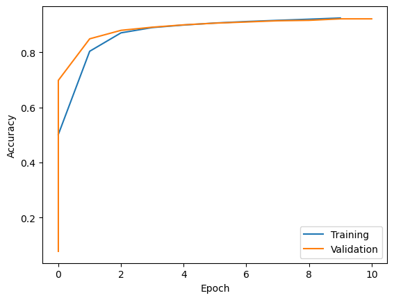

```python
plt.plot(results["epoch"][np.logical_not(np.isnan(results["train_acc"]))],
         results["train_acc"][np.logical_not(np.isnan(results["train_acc"]))],
         label="Training")
plt.plot(results["epoch"][np.logical_not(np.isnan(results["val_acc"]))],
         results["val_acc"][np.logical_not(np.isnan(results["val_acc"]))],
         label="Validation")
plt.legend()
plt.ylabel("Accuracy")
plt.xlabel("Epoch")
plt.show()
```

### Keep these for -each- model

If you print the location and save that info, then you can go back later and enter the path manually to make the comparison plots if needed. Note that you can also use the `version=` option when creating the `CSVLogger` to control exactly what the version subdirectory is named (I will often use this in future code samples). **Be careful** with that method also though, this will allow the logger to *overwrite* previous results.

```python
single_layer_dir = logger.log_dir
single_layer_dir
```

```
'logs/multilayer_example/version_0'
```

```python
wide_layer_dir = logger.log_dir
wide_layer_dir
```

```
'logs/multilayer_example/version_1'
```

```python
deep_layer_dir = logger.log_dir
deep_layer_dir
```

```
'logs/multilayer_example/version_2'
```

# Multi-Model Curve Comparison

```python
results1 = pd.read_csv(single_layer_dir+"/metrics.csv",delimiter=',')
results2 = pd.read_csv(wide_layer_dir+"/metrics.csv",delimiter=',')
results3 = pd.read_csv(deep_layer_dir+"/metrics.csv",delimiter=',')
```

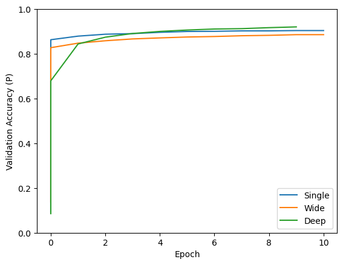

```python
plt.plot(results1["epoch"][np.logical_not(np.isnan(results1["val_acc"]))],
         results1["val_acc"][np.logical_not(np.isnan(results1["val_acc"]))],
         label="Single")
plt.plot(results2["epoch"][np.logical_not(np.isnan(results2["val_acc"]))],
         results2["val_acc"][np.logical_not(np.isnan(results2["val_acc"]))],
         label="Wide")
plt.plot(results3["epoch"][np.logical_not(np.isnan(results3["val_acc"]))],
         results3["val_acc"][np.logical_not(np.isnan(results3["val_acc"]))],
         label="Deep")
plt.ylim([0.0,1.0])
plt.ylabel('Validation Accuracy (P)')
plt.xlabel('Epoch')
plt.legend(loc='lower right')
plt.show()
```